# Update: Understanding GEE

Ward B. Eiling

2024-09-26

## Background: GEE vs. MLM

McNeish et al. (2016) provides a nice summary of the differences

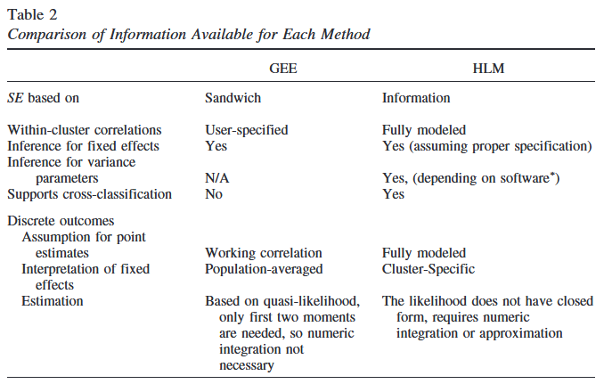

Parameter interpretation

## Background: GEE estimation

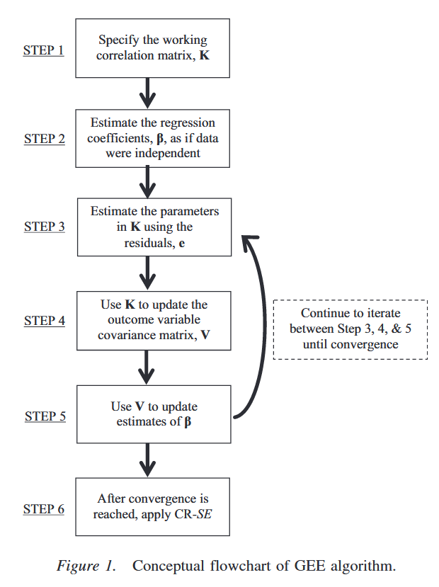

In step 2 we initially fit GLM (assumes independence)

## Example 1: Simulation Specification

To hone in on the understanding of the estimation approaches, we want to keep stable across simulations:

- Continuous variables (predictors, covariates and outcome)
- No missing data
- Number of classes = 50 (recommendation of McNeish et al., 2016)
- Size of classes (i.e., number of timepoints) = 5 (may be too small for random effects of MLM)
- Causal structure ($X \to Y_t$)

And we want to vary:

- MLM - Estimation approaches: ML and REML
- GEE - Working correlation matrix (independence, exchangeable, AR1)

## Example 1: DAG

Let’s draw a DAG where we are estimating the effect of $X$ (sleep-problems) on $Y_t$ (anxiety)

```r
library(dagitty)

dag <- dagitty('dag {
  X -> Y_t
}')

plot(dag)
```

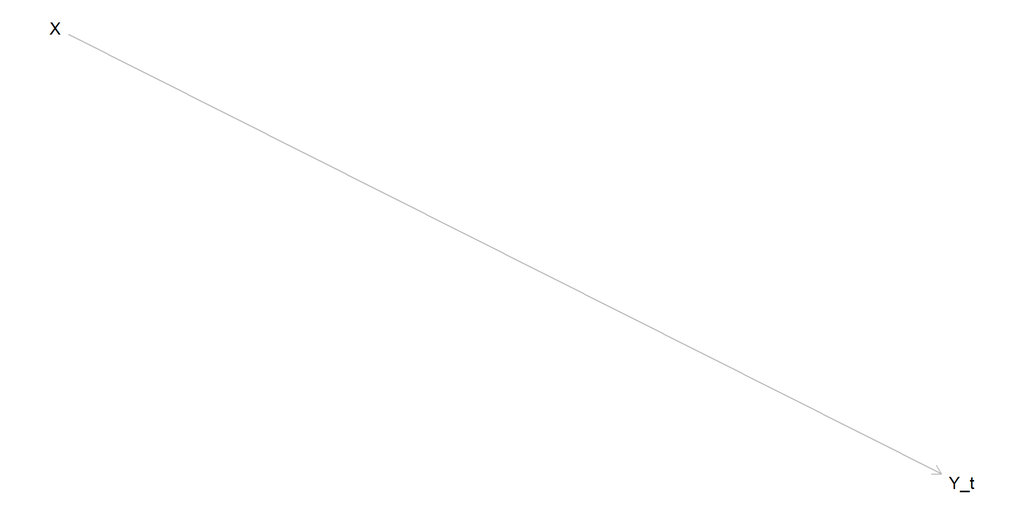

## Example 1: Structural Causal Model

Let’s specify the structural causal model (SCM) for the drawn DAG

$$X_i := \mathcal{N}(5, 1) \quad \text{for} \quad i = 1, \ldots, n_{\text{individuals}}$$
$$Y_{i,t} := 2 + 0.6 \cdot X_i + \epsilon_{i,t} \quad \text{for} \quad i = 1, \ldots, n_{\text{individuals}} \quad \text{and} \quad t = 1, \ldots, n_{\text{measurements}}$$
where $\epsilon_{i,t}$ follows a multivariate normal distribution with mean zero and an exchangeable correlation structure across time points $t$:
$$\epsilon_{i,1}, \ldots, \epsilon_{i,n_{\text{measurements}}} \sim \mathcal{N}(0, \Sigma)$$
The covariance matrix $\Sigma$ has the form:
$$\Sigma = \begin{bmatrix} 1 & \rho & \cdots & \rho \\ \rho & 1 & \cdots & \rho \\ \vdots & \vdots & \ddots & \vdots \\ \rho & \rho & \cdots & 1 \end{bmatrix}$$

with $\rho = 0.7$, representing the exchangeable correlation structure between the errors at different time points within an individual.

## Example 1: Statistical Model Equations

MLM model equations

- $$Y_{ij} = \beta_{0j} + \beta_{1j} X_{ij} + e_{ij}$$
  where $i$ denotes level 1 (time) and $j$ denotes level 2 (individual).
  - $\beta_{0j} = \gamma_{00} + u_{0j}$
  - $\beta_{1j} = \gamma_{10} + u_{1j}$, where $u_{1j} \sim \mathcal{N}(0, \sigma^2_{u1})$

## Example 1: GEE Model